# Sesion 17: Modelos gráficos: Operaciones

Juan Carlos Martinez-Ovando

Primavera 2017

### **Resumen y objetivos**

- Algunas operaciones que pueden definirse sobre `grafos`
- Emplearemos la libreria `igraph` de `R`:

```
install.packages("diagram")
install.packages("igraph")
```

# Algoritmos sobre grafos

Incluidos en la libreria `igraph`:

## A1. Clustering

- `membership`: vector numérico que da el identificador del clúster al que pertenece cada vértice.
- `csize`: vector numérico que da los tamaños de los clusters.
- `No`: constante numérica, número de clusters

```r
require("igraph")
g <- erdos.renyi.game(20, 1/20)
summary(g)
```

```
## IGRAPH U--- 20 11 -- Erdos renyi (gnp) graph
## + attr: name (g/c), type (g/c), loops (g/l), p (g/n)
```

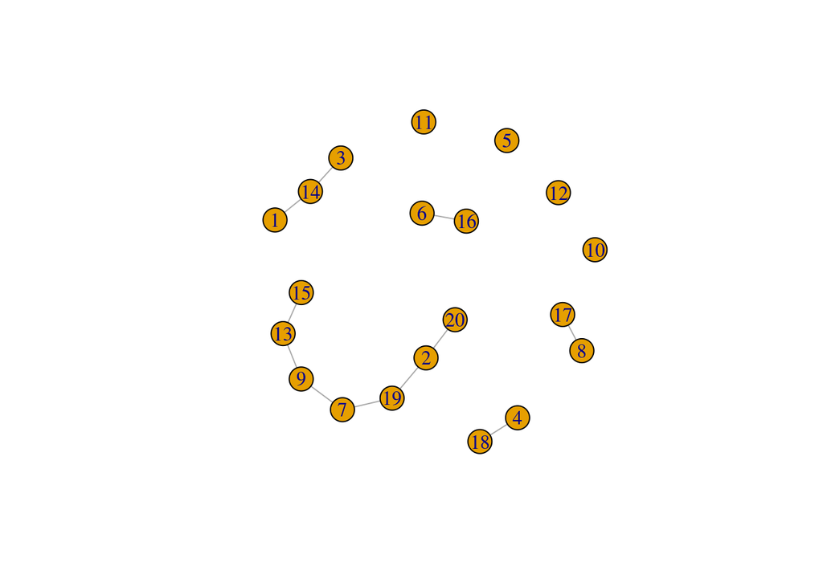

```r
plot(g)
```

```r
clusters(g)
```

```
## $membership
##  [1] 1 2 1 3 4 5 2 6 2 7 8 9 2 1 2 5 6 3 2 2
##
## $csize
## [1] 3 7 2 1 2 2 1 1 1
##
## $no
## [1] 9
```

## A2. Estadisticas sobre grafos

Hay muchas estadísticas que podemos buscar para obtener una idea general de la forma del grafo. En el nivel más alto, podemos ver estadísticas resumidas del grafo mismo. Esto incluye:

- Tamaño (número de `nodos` y `aristas`)
- Densidad, que mide si el grafo es denso ($|E|$ proporcional a $|V|^2$) o escaso ($|E|$ proporcional a $|V|$)
- Conectividad del `grafo` (i.e., si gran parte de los `nodos` puede llegar a los demás) o si está desconectada (muchas islas)
- Diámetro del grafo, que mide la distancia más larga entre dos `nodos` cualesquiera
- `Medidas de reciprocidad` en un grafo dirigido, i.e. ¿cuán simétricas son las relaciones?
- Distribución de `degree`s de entrada / salida

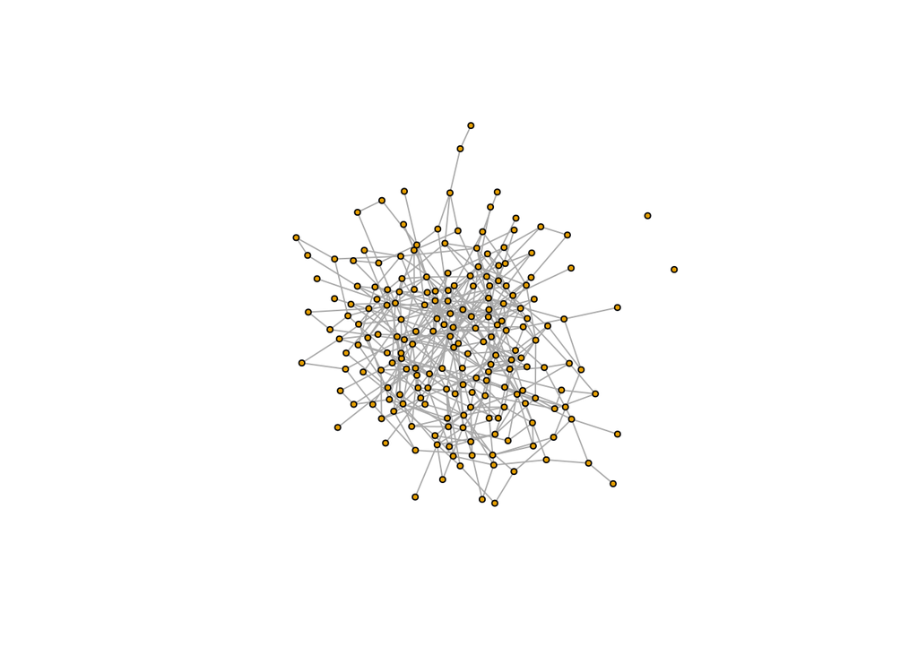

```r
set.seed(121)
# Definimos un grafo aleatorio
g <- erdos.renyi.game(200, 0.02)
plot(g, layout=layout.fruchterman.reingold,
       vertex.label=NA, vertex.size=3)
```

```r
# Numero de nodos
length(V(g))
```

```
## [1] 200
```

```r
# Numero de `edges`
length(E(g))
```

```
## [1] 401
```

```r
# Densidad = Num.edges / Poss.edges
graph.density(g)
```

```
## [1] 0.02015075
```

```r
# Num. islands
clusters(g)$no
```

```
## [1] 3
```

```r
# Coeficienteglobal de agrupamiento
transitivity(g, type="global")
```

```
## [1] 0.028463
```

```r
# `Edge` conectividad
edge.connectivity(g)
```

```
## [1] 0
```

```r
# Adhesion
graph.adhesion(g)
```

```
## [1] 0
```

```r
# Diametro
diameter(g)
```

```
## [1] 10
```

```r
# Reciprocidad
reciprocity(g)
```

```
## [1] 1
```

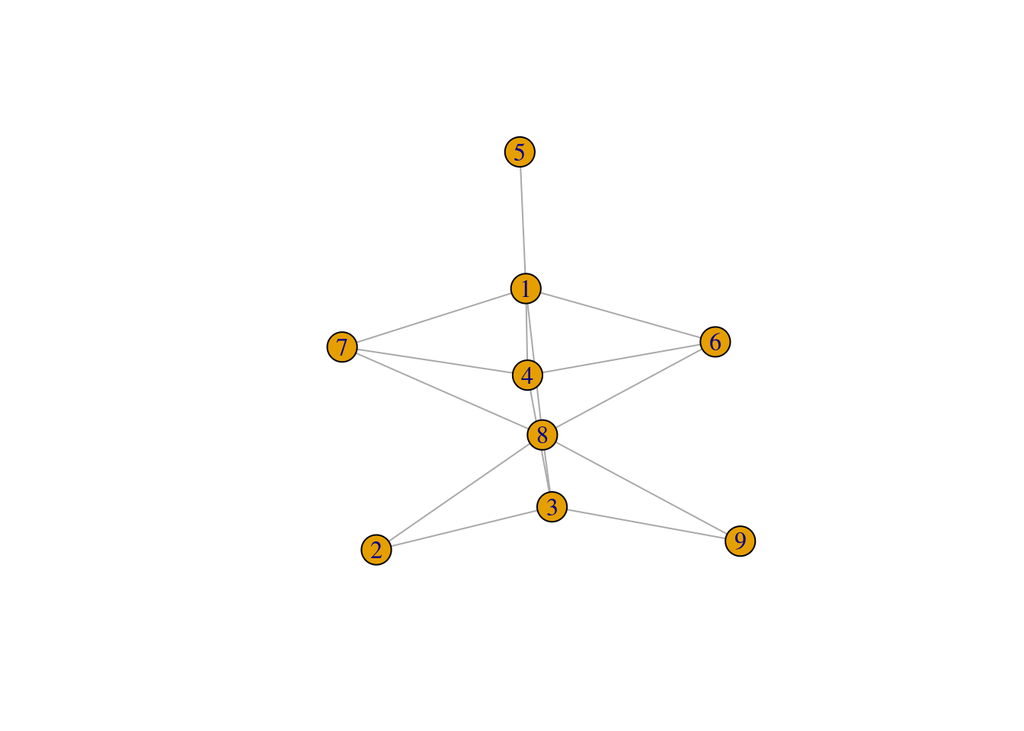

```r
# Creamos un grafo aleatorio de Renyi
g <- erdos.renyi.game(9, 0.5)
plot(g, layout=layout.fruchterman.reingold)
```

```r
# Calculamos la matriz de trayectorias mas cortas, i.e. conectividad
shortest.paths(g)
```

```
##       [,1] [,2] [,3] [,4] [,5] [,6] [,7] [,8] [,9]
##  [1,]    0    2    2    1    1    1    1    1    2
##  [2,]    2    0    1    2    3    2    2    1    2
##  [3,]    2    1    0    1    3    2    2    1    1
##  [4,]    1    2    1    0    2    1    1    2    2
##  [5,]    1    3    3    2    0    2    2    2    3
##  [6,]    1    2    2    1    2    0    2    1    2
##  [7,]    1    2    2    1    2    2    0    1    2
##  [8,]    1    1    1    2    2    1    1    0    1
##  [9,]    2    2    1    2    3    2    2    1    0
```

```r
M <- matrix(rep(0, 81), nrow=9)
for (i in 1:9) {
  for (j in 1:9) {
    if (i == j) {
      M[i, j] <- -1
    } else {
      M[i, j] <- edge.connectivity(g, i, j)
    }
  }
}
M
```

```
##       [,1] [,2] [,3] [,4] [,5] [,6] [,7] [,8] [,9]
##  [1,]   -1    2    4    4    1    3    3    4    2
##  [2,]    2   -1    2    2    1    2    2    2    2
##  [3,]    4    2   -1    4    1    3    3    4    2
##  [4,]    4    2    4   -1    1    3    3    4    2
##  [5,]    1    1    1    1   -1    1    1    1    1
##  [6,]    3    2    3    3    1   -1    3    3    2
##  [7,]    3    2    3    3    1    3   -1    3    2
##  [8,]    4    2    4    4    1    3    3   -1    2
##  [9,]    2    2    2    2    1    2    2    2   -1
```

## A3. Medidas de centralidad

En el nivel de grano fino, podemos ver estadísticas de `nodos` individuales, como una medida de centralidad acerca de la importancia social de un `nodo`

- La `centralidad de grados` otorga una puntuación más alta a un `nodo` que tiene un alto grado de entrada / salida
- La `centralidad de proximidad` da una puntuación más alta a un `nodo` que tiene una distancia de trayecto corto a todos los otros `nodos`
- La `centralidad entre estados` da una puntuación más alta a un `nodo` que se encuentra en muchos caminos más cortos de otros pares de `nodos`
- La `centralidad del vector` propio otorga una puntuación más alta a un nodo si se conecta a muchos nodos de alta puntuación
- El `coeficiente de cluster local` mide cómo los vecinos deun `nodo` están interconectados entre sí, lo que significa que el `nodo` se vuelve menos importante.

```r
# Degree
degree(g)
```

```
## [1] 5 2 4 4 1 3 3 6 2
```

```r
# Closeness
closeness(g)
```

```
## [1] 0.09090909 0.06666667 0.07692308 0.08333333 0.05555556 0.07692308
## [7] 0.07692308 0.10000000 0.06666667
```

```r
# Betweenness
betweenness(g)
```

```
## [1]  7.583333  0.000000  2.750000  2.333333  0.000000  0.250000  0.250000
## [8] 10.833333  0.000000
```

```r
# Coeficiente local de agrupamiento
transitivity(g, type="local")
```

```
## [1] 0.4000000 1.0000000 0.3333333 0.3333333       NaN 0.6666667 0.6666667
## [8] 0.2666667 1.0000000
```

```r
# Eigenvector centrality
evcent(g)$vector
```

```
## [1] 0.8815813 0.4407906 0.6911719 0.7702228 0.2297772 0.6911719 0.6911719
## [8] 1.0000000 0.4407906
```

```r
order(degree(g))
```

```
## [1] 5 2 9 6 7 3 4 1 8
```

```r
order(closeness(g))
```

```
## [1] 5 2 9 3 6 7 4 1 8
```

```r
order(betweenness(g))
```

```
## [1] 2 5 9 6 7 4 3 1 8
```

```r
order(evcent(g)$vector)
```

```
## [1] 5 2 9 6 7 3 4 1 8
```

En estudios sociales, Drew Conway ha encontrado que las personas con baja centralidad en `eingenvector` pero alta centralidad en `betweeness` son importantes guardianes, mientras que las personas con alta centralidad en `eigenvector` pero baja centralidad en `betweeness` tienen contacto directo con personas importantes. Por lo tanto, permite representar la centralidad de `eigenvector` contra la centralidad de `betweeness`.

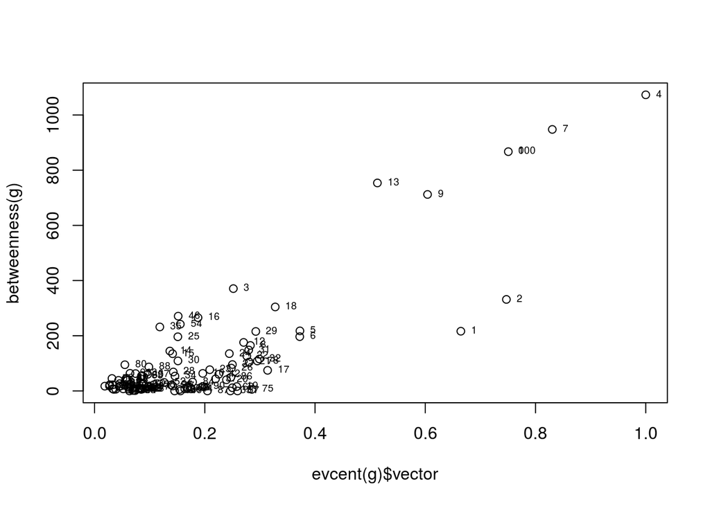

```r
# Creamos un grafo
g1 <- barabasi.game(100, directed=F)
g2 <- barabasi.game(100, directed=F)
g <- g1 %u% g2
lay <- layout.fruchterman.reingold(g)
# Graficamos la centralidad `eigevector` y `betweenness`
plot(evcent(g)$vector, betweenness(g))
text(evcent(g)$vector, betweenness(g), 0:100,
       cex=0.6, pos=4)
```

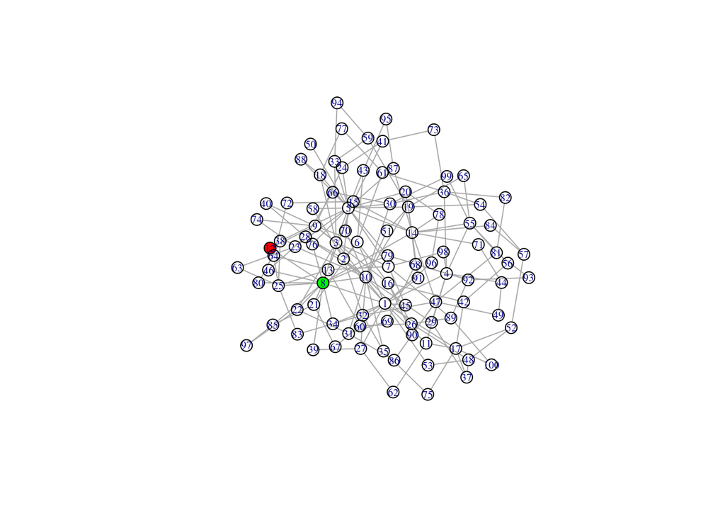

```r
V(g)[12]$color <- 'red'
V(g)[8]$color <- 'green'
plot(g, layout=lay, vertex.size=8,vertex.label.cex=0.6)
```

## Referencias

- **Lauritzen** - Graphical Models
- **Koller y Firiedman** - Probabilistic Graphical Models Principles and Techniques
- **Hoejsgaard et al** - Graphical models in R